# NDH802 - Hypothesis testing

Chapter 9 and 10

## 9.37

The probability of type II error is: $\beta = P(\bar{x}\le 5.041|\mu = \text{each of the mu given in the sub-questions})$. $\text{power} = 1 - \beta$.

```r
#we calculate this similarly to the way we solve exercises in previous chapters
beta_a = pnorm(q = 5.041, mean = 5.1, sd = 0.1/sqrt(16))
power_a = 1 - beta_a

beta_b = pnorm(q = 5.041, mean = 5.03, sd = 0.1/sqrt(16))
power_b = 1 - beta_b

beta_c = pnorm(q = 5.041, mean = 5.15, sd = 0.1/sqrt(16))
power_c = 1 - beta_c

beta_d = pnorm(q = 5.041, mean = 5.07, sd = 0.1/sqrt(16))
power_d = 1 - beta_d
```

## 9.41

Summarize the question:

```r
n = 1562
x_bar = 4.27
s = 1.32
mu_a = 4
alpha = 0.01
```

a. Two-sided test at $\alpha = 0.01$

$$\begin{align*}
H_o&: \mu_a = 4 \\
H_1&: \mu_a \ne 4
\end{align*}$$

As many of you ask for “the book way”:

```r
se = s/sqrt(n)
z_alpha = qnorm(p = alpha/2, lower.tail = F)
UCL = mu_a + z_alpha*se
LCL = mu_a - z_alpha*se
```

4.27 > 4.09, or $\bar{x}>$ UCL, we reject the null hypothesis.

```r
mu_b = 3.95
beta = pnorm(q = LCL, mean = mu_b, sd = se, lower.tail = F)
```

DON’T freak out! The following code is for illustration purpose only and WON’T be in the exam. Simply run the whole code chunk for the plot to show.

The curve on the right, with $\mu = \mu_a = 4$, represents the distribution of the sample mean based on the null hypothesis in question a. The curve on the left, with $\mu = \mu_b = 3.95$, represents the distribution of the sample mean based on the true population mean in question b. The red area is the $\alpha$ in question a, based on which we calculate the critical value. The green area is the $\beta$ that we calculated in question b.

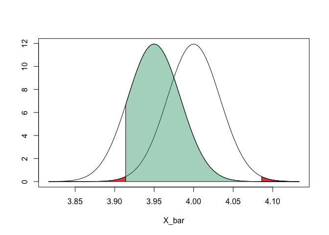

## 9.65

$$\begin{align*}
H_o: \mu \le 40 \\
H_1: \mu > 40
\end{align*}$$

```r
#summrize the assumption
n_965 = 125
xbar_965 = 40.9
s_squared_965 = 65

t_965 = (xbar_965 - 40)/sqrt(s_squared_965/n_965)
pvalue_965 = pt(q = t_965, df = n_965-1, lower.tail = FALSE)
```

p-value = 0.1071775 is not very small, hence the claim is not very strong.

## 10.4

$$\begin{align*}
H_o: \mu_2 = \mu_1 \\
H_1: \mu_2 > \mu_1
\end{align*}$$

```r
#load data into your Global environment
price <- read.csv("https://tinyurl.com/HouseSellingPrice")[, -1]

#t.test on all data
t.test(x = price$Sale.2.Price,
       y = price$Sale.1.Price,
       #here we specify paired = TRUE because we want to do matched t-test
       paired = TRUE,
       #here we specify alternative = "greater" because that is our H1
       alternative = "greater")
```

```
##
##  Paired t-test
##
## data:  price$Sale.2.Price and price$Sale.1.Price
## t = 53.675, df = 3999, p-value < 2.2e-16
## alternative hypothesis: true difference in means is greater than 0
## 95 percent confidence interval:
##  21579.17      Inf
## sample estimates:
## mean of the differences
##                22261.52
```

```r
#t.test on Atlanta data
t.test(x = price[price$Atlanta == 1, "Sale.2.Price"],
       y = price[price$Atlanta == 1, "Sale.1.Price"],
       paired = TRUE, alternative = "greater")
```

```
##
##  Paired t-test
##
## data:  price[price$Atlanta == 1, "Sale.2.Price"] and price[price$Atlanta == 1, "Sale.1.Price"]
## t = 31.439, df = 999, p-value < 2.2e-16
## alternative hypothesis: true difference in means is greater than 0
## 95 percent confidence interval:
##  15696.58      Inf
## sample estimates:
## mean of the differences
##                   16564
```

## 10.34

Here I chose $\alpha = 0.05$ for example, feel free to choose other $\alpha$ as you reason.

```r
nutrition <- read.csv("https://tinyurl.com/FoodNutritionAtlas")[, -1]
#summary(nutrition)
```

$$\begin{align*}
H_o: \mu_{adult-metro} = \mu_{adult-nonmetro}\\
H_1: \mu_{adult-metro} \ne \mu_{adult-nonmetro}
\end{align*}$$

```r
#The following code is simply data manipulation
#"PCT_OBESE_ADULTS" of adults living in metro cities
adult_metro = nutrition[nutrition$metro == 1, "PCT_OBESE_ADULTS"]
#"PCT_OBESE_ADULTS" of adults living in non-metro cities
adult_nonmetro = nutrition[nutrition$metro == 0, "PCT_OBESE_ADULTS"]
#perform the t test
t.test(x = adult_metro,
       y = adult_nonmetro,
       #we specify alternative = "two.sided" because H1 is "not equal"
       alternative = "two.sided")
```

```
##
##  Welch Two Sample t-test
##
## data:  adult_metro and adult_nonmetro
## t = -6.8361, df = 2192.3, p-value = 1.051e-11
## alternative hypothesis: true difference in means is not equal to 0
## 95 percent confidence interval:
##  -1.1920048 -0.6605671
## sample estimates:
## mean of x mean of y
##  27.68356  28.60985
```

p-value is smaller than alpha, we reject the null hypothesis.

$$\begin{align*}
H_o: \mu_{child-metro} = \mu_{child-nonmetro}\\
H_1: \mu_{child-metro} \ne \mu_{child-nonmetro}
\end{align*}$$

```r
#This is similar, but on the children
child_metro = nutrition[nutrition$metro == 1, "PCT_Child_OBESITY"]
child_nonmetro = nutrition[nutrition$metro == 0, "PCT_Child_OBESITY"]
t.test(x = child_metro, y = child_nonmetro, alternative = "two.sided")
```

```
##
##  Welch Two Sample t-test
##
## data:  child_metro and child_nonmetro
## t = 0.89226, df = 2300.1, p-value = 0.3723
## alternative hypothesis: true difference in means is not equal to 0
## 95 percent confidence interval:
##  -0.1542429  0.4117915
## sample estimates:
## mean of x mean of y
##  14.26857  14.13980
```

p-value is greater than alpha, we fail to reject the null hypothesis.

## 10.48

$\alpha = 0.05$

$$\begin{align*}
H_o: \mu_{SalesO} = \mu_{SalesC}\\
H_1: \mu_{SalesO} > \mu_{SalesC}
\end{align*}$$

```r
ole <- read.csv("https://tinyurl.com/OleSales")[, -1]

t.test(x = ole$Olesales,
       y = ole$Carlsale,
       alternative = "greater")
```

```
##
##  Welch Two Sample t-test
##
## data:  ole$Olesales and ole$Carlsale
## t = 2.5171, df = 294.57, p-value = 0.006181
## alternative hypothesis: true difference in means is greater than 0
## 95 percent confidence interval:
##  475.0596      Inf
## sample estimates:
## mean of x mean of y
##  3791.128  2412.038
```

p-value < alpha, we reject the null hypothesis.

$$\begin{align*}
H_o: \mu_{PriceO} = \mu_{PriceC}\\
H_1: \mu_{PriceO} \ne \mu_{PriceO}
\end{align*}$$

```r
t.test(x = ole$Oleprice,
       y = ole$Carlpric,
       alternative = "two.sided")
```

```
##
##  Welch Two Sample t-test
##
## data:  ole$Oleprice and ole$Carlpric
## t = -0.047883, df = 303.65, p-value = 0.9618
## alternative hypothesis: true difference in means is not equal to 0
## 95 percent confidence interval:
##  -0.02968326  0.02827300
## sample estimates:
## mean of x mean of y
## 0.8187820 0.8194872
```

p-value > alpha, we fail to reject the null hypothesis.

## 10.52

Let $x_1, x_2$ denote the HEI scores of the immigrants in the first and second interview; $y_1, y_2$ denote the HEI scores of the natives in the first and second interview. Suppose $\alpha = 0.01$.

```r
#data prep
hei <- read.csv("https://tinyurl.com/HEIInterview")[, -1]

x1 = hei[hei$immigrant == 1 & hei$daycode == 1, "HEI2005"]
y1 = hei[hei$immigrant == 0 & hei$daycode == 1, "HEI2005"]
x2 = hei[hei$immigrant == 1 & hei$daycode == 2, "HEI2005"]
y2 = hei[hei$immigrant == 0 & hei$daycode == 2, "HEI2005"]
```

Below are the hypotheses we want to test for the first interview.

$$\begin{align*}
H_o: \mu_{x1} = \mu_{y1}\\
H_1: \mu_{x1} > \mu_{y1}
\end{align*}$$

```r
#difference in diet from the first interview
t.test(x = x1, y = y1, alternative = "greater")
```

```
##
##  Welch Two Sample t-test
##
## data:  x1 and y1
## t = 12.586, df = 1352.7, p-value < 2.2e-16
## alternative hypothesis: true difference in means is greater than 0
## 95 percent confidence interval:
##  5.740486      Inf
## sample estimates:
## mean of x mean of y
##  57.30373  50.69956
```

p-value < alpha. We reject the null hypothesis.

Below are the hypotheses we want to test for the second interview.

$$\begin{align*}
H_o: \mu_{x2} = \mu_{y2}\\
H_1: \mu_{x2} > \mu_{y2}
\end{align*}$$

```r
#difference in diet from the second interview
t.test(x = x2, y = y2, alternative = "greater")
```

```
##
##  Welch Two Sample t-test
##
## data:  x2 and y2
## t = 12.698, df = 1228.2, p-value < 2.2e-16
## alternative hypothesis: true difference in means is greater than 0
## 95 percent confidence interval:
##  6.156651      Inf
## sample estimates:
## mean of x mean of y
##  60.07289  52.99928
```

## 10.56

Let $f_1, f_2$ denote the daily cost of women in the first and second interview; $m_1, m_2$ denote the daily cost of men in the first and second interview.

```r
#data prep
f1 = hei[hei$female == 1 & hei$daycode == 1, "daily_cost"]
m1 = hei[hei$female == 0 & hei$daycode == 1, "daily_cost"]
f2 = hei[hei$female == 1 & hei$daycode == 2, "daily_cost"]
m2 = hei[hei$female == 0 & hei$daycode == 2, "daily_cost"]
```

Below are the hypotheses we want to test for the first interview.
$$\begin{align*}
H_o: \mu_{f1} = \mu_{m1} \\
H_1: \mu_{f1} < \mu_{m1}
\end{align*}$$

```r
#difference in daily cost from the first interview
t.test(x = f1, y = m1, alternative = "less")
```

```
##
##  Welch Two Sample t-test
##
## data:  f1 and m1
## t = -13.007, df = 3956.7, p-value < 2.2e-16
## alternative hypothesis: true difference in means is less than 0
## 95 percent confidence interval:
##      -Inf -1.03636
## sample estimates:
## mean of x mean of y
##  4.650782  5.837215
```

p-value < alpha. We reject the null hypothesis.

Below are the hypotheses we want to test for the second interview.

$$\begin{align*}
H_o: \mu_{f2} = \mu_{m2} \\
H_1: \mu_{f2} < \mu_{m2}
\end{align*}$$

```r
#difference in daily cost from the seond interview
t.test(x = f2, y = m2, alternative = "less")
```

```
##
##  Welch Two Sample t-test
##
## data:  f2 and m2
## t = -12.089, df = 3658, p-value < 2.2e-16
## alternative hypothesis: true difference in means is less than 0
## 95 percent confidence interval:
##        -Inf -0.9433771
## sample estimates:
## mean of x mean of y
##  4.490478  5.582471
```